# Two-Way ANOVA

ANOVA可以分析两个或多个因子的复合效应，ANOVA的设计越复杂，对结果的解析同样会变得很复杂。

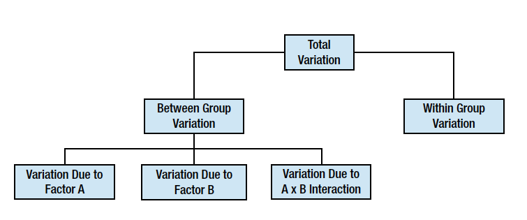

双向ANOVA分析是单向ANOVA的扩展，分析两个因素，我们称之为A和B，假如A有r个水平，B有c个水平，则总共有rxc个分组，每个分组的数据数目要一致。

## 前提条件

使用Two-Way ANOVA，需要满足以下假设：

- 总体须是正态分布或接近于正态分布
- 样本必须是独立样本
- 方差齐性
- 分组样本量一样

## 零假设

双向ANOVA能够同时检验3个零假设：

- 单独考虑A因素，总体均值间没有差别。这相当于对A因子进行单向ANOVA
- 单独考虑B因素，总体均值间没有差别。这相当于对B因子进行单向ANOVA
- A和B两个因素，没有相互作用。这相当于使用二联表进行独立性分析

## 方差计算

```r
data <- read.table("data/gender_dose.tsv", header = TRUE)
data
```

```
##    Observation Gender Dosage Alertness
## 1            1      m      a         8
## 2            2      m      a        12
## 3            3      m      a        13
## 4            4      m      a        12
## 5            5      m      b         6
## 6            6      m      b         7
## 7            7      m      b        23
## 8            8      m      b        14
## 9            9      f      a        15
## 10          10      f      a        12
## 11          11      f      a        22
## 12          12      f      a        14
## 13          13      f      b        15
## 14          14      f      b        12
## 15          15      f      b        18
## 16          16      f      b        22
```

我们来分析上面这份数据，看Gender和Dosage两个因素对Alerness水平的影响。Gender和Dosage都是2个水平，这是最简单的2x2设计。 进行双向方差分析，需要计算6个方差。

### 总方差

不对数据进行分组，计算出来的方差，为总方差，自由度为样本量减1.

```r
grand.mean <- with(data, mean(Alertness))
N <- with(data, length(Alertness))
N
```

```
## [1] 16
```

```r
SS.tot <- with(data, sum((Alertness - grand.mean)^2))
SS.tot
```

```
## [1] 392.9
```

### 单元格方差

```r
require(plyr)
grp <- ddply(data, .(Gender, Dosage), function(x) data.frame(n = length(x$Alertness),
    m = mean(x$Alertness)))
grp
```

```
##   Gender Dosage n     m
## 1      f      a 4 15.75
## 2      f      b 4 16.75
## 3      m      a 4 11.25
## 4      m      b 4 12.50
```

```r
SS.cells <- with(grp, sum(n * (m - grand.mean)^2))
SS.cells
```

```
## [1] 81.69
```

### 因素A的方差

只考虑因素A，对于这个数据来说，是性别因素，只使用性别因素对数据进行分组，按单向ANOVA分析一样，计算组间方差：

```r
Am <- with(data, tapply(Alertness, Gender, mean))
An <- with(data, tapply(Alertness, Gender, length))
SS.gender <- sum(An * (Am - grand.mean)^2)
SS.gender
```

```
## [1] 76.56
```

自由度是因素A的水平减1，既r-1，这里r=2，所以df=1。

### 因素B的方差

只考虑因素B，对于这个数据来说，是药剂用量因素，只使用dosage因素对数据进行分组，按单向ANOVA分析一样，计算组间方差：

```r
Bm <- with(data, tapply(Alertness, Dosage, mean))
Bn <- with(data, tapply(Alertness, Dosage, length))
SS.dosage <- sum(Bn * (Bm - grand.mean)^2)
SS.dosage
```

```
## [1] 5.062
```

自由度是因素B的水平减1，既c-1，这里c=2，所以df=1。

### 因素A和B相互作用的方差

单元格方差由A因素和B因素组成，可以拆分为因素A的方差、因素B的方差和AB互作的方差，即： \[ SS_{cells} = SS_A + SS_B + SS_{AB}\] 所以A和B互作的方差： \[ SS_{AB} = SS_{cells} - SS_A - SS_B\]

```r
SS.gender.dosage <- SS.cells - SS.gender - SS.dosage
SS.gender.dosage
```

```
## [1] 0.0625
```

自由度是A的自由度乘以B的自由度，即：(r-1)(c-1)。

### 误差方差

最后是组内方差，它度量误差，方差分析和线性回归是高度一致的，在R的aov函数里，会把误差方差写成残差方差，这其实来自于线性回归。

```r
dw <- ddply(data, .(Gender, Dosage), function(x) x$Alertness - mean(x$Alertness))
dw
```

```
##   Gender Dosage    V1    V2    V3    V4
## 1      f      a -0.75 -3.75  6.25 -1.75
## 2      f      b -1.75 -4.75  1.25  5.25
## 3      m      a -3.25  0.75  1.75  0.75
## 4      m      b -6.50 -5.50 10.50  1.50
```

```r
sum(dw[, -c(1, 2)]^2)
```

```
## [1] 311.2
```

上面按照A和B两个因素，分成rxc组，按单向ANOVA分析方法，计算组内方差。 实际上，误差方差等于总方差减去单元格方差，也就是总方差中不能由因素A和B解释的，就是误差方差：

```r
SS.err = SS.tot - SS.cells
SS.err
```

```
## [1] 311.2
```

自由度是总自由度减去A，B和AB互作的自由度，即(N-1) - (r-1) - (c-1) - (r-1)(c-1).

## p值计算

计算了这6个方差之后，就要以计算F值，进而计算p值。计算F值需要用均方，即方差除以自由度。分子相当于信号，而分母相当于噪声。信噪比足够高，则这个因素有作用。

```r
pf(SS.gender/1/(SS.err/12), df1 = 1, df2 = 12, lower.tail = F)
```

```
## [1] 0.1115
```

```r
pf(SS.dosage/1/(SS.err/12), df1 = 1, df2 = 12, lower.tail = F)
```

```
## [1] 0.6665
```

```r
pf(SS.gender.dosage/1/(SS.err/12), df1 = 1, df2 = 12, lower.tail = F)
```

```
## [1] 0.9617
```

上面分别看了Gender, Dosage, Gender和Dosage相互作用的p值，分别对应于前面提到的三个零假设。

## ANOVA using R

stats包中的aov()函数，可以进行双向方差分析，我们并不需要手工计算这么多的统计量。

```r
summary(with(data, aov(Alertness ~ Gender * Dosage)))
```

```
##               Df Sum Sq Mean Sq F value Pr(>F)
## Gender         1   76.6    76.6    2.95   0.11
## Dosage         1    5.1     5.1    0.20   0.67
## Gender:Dosage  1    0.1     0.1    0.00   0.96
## Residuals     12  311.2    25.9
```

虽然这里相互作用没有显著性，但做为演示，依然可以画一下相互作用图，使用stats包提供的interaction.plot，如果有显著性，可以从图中看出效应。

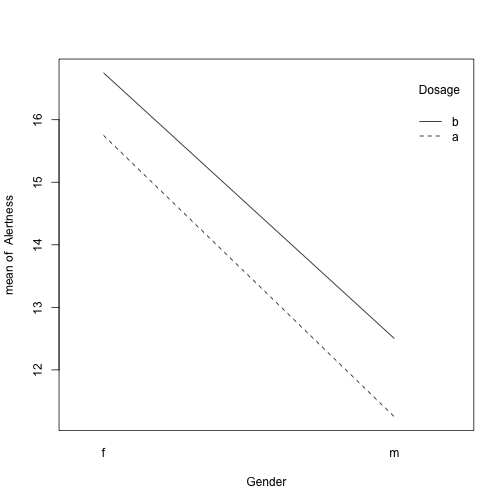

```r
with(data, interaction.plot(Gender, Dosage, Alertness))
```

这个图其实就是以Gender为X轴，按Dosage进行分组，以分组的Alertness均值为Y轴，进行画图，自己使用ggplot2来画也是非常简单的，还可以给均值加上errorbar或confidence interval，都是很容易的事情。

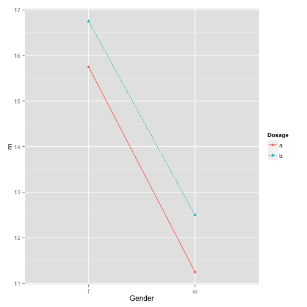

```r
require(ggplot2)
grp <- ddply(data, .(Gender, Dosage), function(x) data.frame(m = mean(x$Alertness)))
ggplot(grp, aes(Gender, m, group = Dosage, shape = Dosage, color = Dosage, linetype = Dosage)) +
    geom_point() + geom_line()
```

对于分组数据均值是否有差异，也可以画boxplot或者是使用均值和置信区间来画图。

```
2013-06-26
```

## 欢迎请作者一杯咖啡

[figure not shown]

## 访问统计

[figure not shown]